# Parameter Estimation

Applied Statistics

MTH-361A | Spring 2026 | University of Portland

# Objectives

- **Introduce confidence intervals**
- **Know how to compute confidence intervals**
- **Develop an understanding of interpreting confidence intervals**

# Confidence Intervals

A plausible range of values for the population parameter is called a *confidence interval*.

**Fishing analogy:**

A confidence interval is like using a fishing net, rather than a spear, to catch fish in a murky lake.

- *Parameter (the fish):* The true population parameter (e.g., mean fish length). This is assumed to be fixed but unknown.
- *Sample statistic (the catch):* The observation (e.g., the data collected from the lake) and the point estimate (e.g., sample mean fish length).

**The interval:**

We need to set the size of the fishing net first before casting it into the lake.

- *Confidence level (the net size):* A higher confidence level (e.g., 99%) means a wider, larger net, increasing the chance of catching the fish.
- *Confidence interval (the net):* The range of values calculated from the sample.

$\star$ If we report a point estimate, we probably won’t hit the exact population parameter. If we report a range of plausible values we have a good shot at capturing the parameter.

# Spam Emails

Suppose we want to estimate the *number* of spam emails of an account.

**Data summary:**

| Not Spam | Spam |
| --- | --- |
| 184 | 16 |

- The data shows that there are $16$ spam emails out of $200$ emails.
- The population of interest is all emails of one account.
- The data we have is a random sample from the population.

**Point estimate:**

- The *sample statistic* is
  $$\overline{x} = 16,$$
  which is our *point estimate*.
- $\overline{x}$ is the number of spam emails, an estimate to an unknown *population parameter*.

$\star$ For the purpose of this example, the sample mean notation $\overline{x}$ can be thought of as the mean of a binomial r.v..

# Sampling Distribution

The point estimate for the number of spam emails is $\overline{x} = 16$ and the sample size is $n = 200$.

**Assumptions:**

- The emails are independently sampled from the same account
- The probability of getting a randomly selected spam email is fixed.
- We assume that CLT conditions are satisfied.
- The sampling distribution of the number of spam emails exhibits a binomial distribution.

**Sampling distribution of $\overline{x}$:**

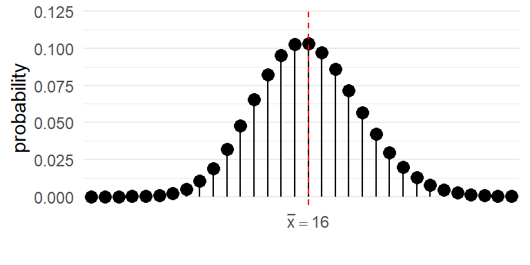

$\star$ The domain of this distribution is $0 \le x \le 200$ (the graph is truncated) because there are $n = 200$ samples and the $x$ value is the number of spam emails out of $n$, where it could be $0$, $200$, or in between.

# Confidence Interval of the Number of Spam Emails

The confidence level is a probability that we set. This is how wide our interval is going to be.

**Confidence Level:**

- Suppose we want a “$90$% confidence interval”. So, the confidence level is $0.90$.
- This is the interval probability of the sampling distribution.
- The goal is to find $a$ and $b$, so that
  $$P(a \le \overline{X} \le b) \approx
  0.90,$$
  where $X$ is a binomial r.v..
- The middle probability is $0.90$ and the tail probabilities sums to $0.10$, with individual tails to be $0.05$, assuming symmetry.
- Probability components:
  - lower bound: $\displaystyle P(\overline{X} \le a) \approx 0.05 \longrightarrow a = 10$
  - upper bound: $\displaystyle P(\overline{X} \le b) \approx 0.95 \longrightarrow b = 23$

**Confidence Interval:**

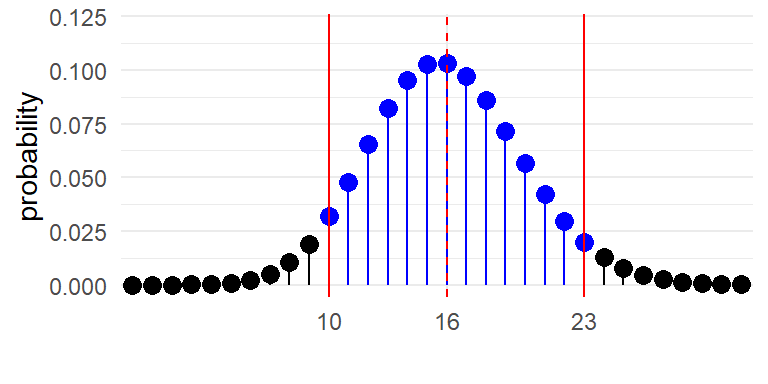

$$10 \le \overline{x} \le 23$$

$\star$ Interpreting this interval requires you to understand how CLT works and a basic understanding of the frequentist interpretation of probability.

**Using R:**

```r
cl <- 0.90 # confidence level
cl_tail <- 1-cl # tail probabilities
lb <- qbinom(cl_tail/2,200,16/200) # lower bound
ub <- qbinom(cl+(cl_tail/2),200,16/200) # upper bound
c(lb,ub) # confidence interval as an ordered list
```

```
## [1] 10 23
```

# Normal Approximation

We have $16$ spam emails and $184$ not spam emails, both are more than $10$, and the sample size $n = 200$ is considered large enough. This *rule of thumb* says that we can approximate the binomial using the normal distribution.

**Normal approximation:**

- The normal approximation to the binomial would yield:
  $$\begin{aligned}
  \overline{x} & = n\hat{p} \longleftarrow \text{ sample mean} \\
  s^2 & = n\hat{p}(1-\hat{p}) \longleftarrow \text{sample variance}
  \end{aligned}$$
- Note that
  $$\hat{p} = \frac{\text{number
  of spam emails}}{n}.$$
  This is known as the sample proportion.
- So, $\displaystyle \hat{p} = \frac{16}{200} = 0.08$.

**Confidence interval assuming normality:**

$$\overline{x} \pm z^* \cdot SE$$
where $SE$ is called the *standard error*. Here, $\displaystyle SE = \sqrt{n\hat{p}(1-\hat{p})}$. The term $z^*$ is called the critical value, which can be computed using R.

So, the interval is

$$\begin{aligned}
\overline{x} & \pm z^* \cdot \sqrt{n\hat{p}(1-\hat{p})} \\
16 & \pm 1.645\left(\sqrt{200(0.08)(1-0.08)})\right)
\end{aligned}$$

$$9.689 \le \overline{x} \le
22.311$$

**Using R:**

```r
cl <- 0.90 # confidence level
cl_tail <- 1-cl # tail probabilities
lb <- qnorm(cl_tail/2,16,sqrt(200*0.08*(1-0.08))) # lower bound
ub <- qnorm(cl+(cl_tail/2),16,sqrt(200*0.08*(1-0.08))) # upper bound
c(lb,ub) # confidence interval as an ordered list
```

```
## [1]  9.689247 22.310753
```

# Facebook’s categorization of user interests

Most commercial websites (e.g. social media platforms, news out- lets, online retailers) collect a data about their users’ behaviors and use these data to deliver targeted content, recommendations, and ads.

To understand whether Americans think their lives line up with how the algorithm-driven classification systems categorizes them, Pew Research asked **a representative sample of 850 American Facebook users** how accurately they feel the list of categories Facebook has listed for them on the page of their supposed interests actually represents them and their interests. **67% of the respondents said that the listed categories were accurate**.

Estimate the true proportion of American Facebook users who think the Facebook categorizes their interests accurately.

# Point Estimate and Standard Error

The goal of parameter estimation is to find a range of possible values (confidence interval).

**Given information**

- $\hat{p} = 0.67 \longleftarrow \text{point estimate}$
- $n = 850 \longleftarrow \text{sample size}$
  - The expected number of users who think the Facebook categorizes their interests accurately is $850 \times 0.67 \approx 569.5$ (569 or 570).
  - There around 280.5 (280 or 281) users think the opposite.
- Let $p$ bet he true population proportion and $\hat{p}$ be the sample proportion.

**The Confidence Interval**

We want to find the 95% confidence interval using the formula:
$$\text{point estimate} \pm 1.96 \times
\text{SE}$$
where **SE is the standard error**.

This can be written as
$$\begin{aligned}
0.67 & \pm 1.96 \times \sqrt{\frac{0.67 (1-0.67)}{850}} \\
0.67 & \pm 1.96 \times 0.0161 \\
& \longrightarrow (0.67-0.0316,0.67+0.0316) \\
& \longrightarrow (0.6384,0.7016)
\end{aligned}$$

Thus, the 95% interval for estimating the true $p$ is between 0.6384 and 0.7016.

# Interpretation

$\dagger$ Why do we interpret the confidence interval this way?

# What does 95% Confident Mean?

Suppose we took many samples and built a confidence interval from each sample using the equation
$$\text{point
estimate} \pm 1.96 \times \text{standard error}.$$

Then about 95% of those intervals would contain the true population proportion ($p$).

# Width of an interval

If we want to be more certain that we capture the population parameter, i.e. increase our confidence level, should we use a wider interval or a smaller interval?

$\star$ A wider interval.

Can you see any drawbacks to using a wider interval?

$\star$ If the interval is too wide it may not be very informative.

# Changing the Confidence Level

$$\text{point estimate} \pm z^{\star}
\times \text{SE}.$$

- In a confidence interval, $z^{\star} \times \text{SE}$ is called the **margin of error**, and for a given sample, the margin of error changes as the confidence level changes.
- In order to change the confidence level we need to adjust $z^{\star}$ in the above formula.
- Commonly used confidence levels in practice are 90%, 95%, 98%, and 99%.
- For a 95% confidence interval, $z^{\star} = 1.96$.
- However, using the standard normal distribution, it is possible to find the appropriate $z^{\star}$ for any confidence level.

# 95% Confidence Interval

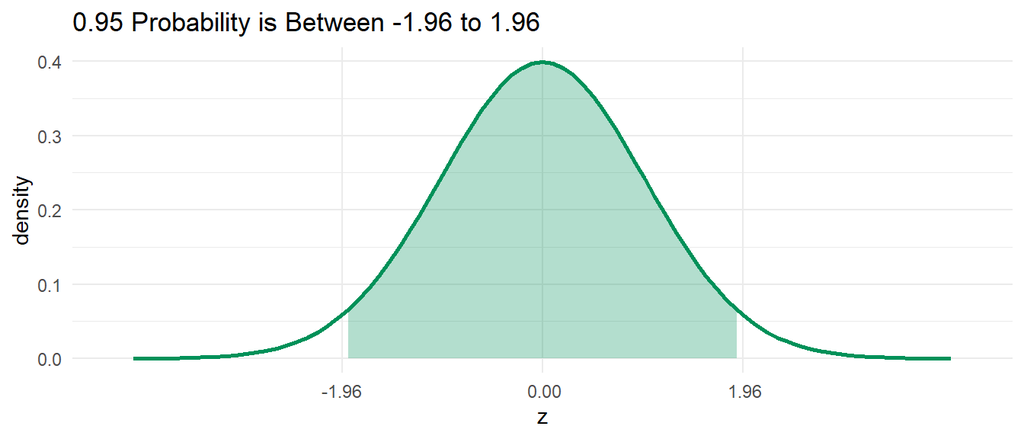

# 99.7% Confidence Interval

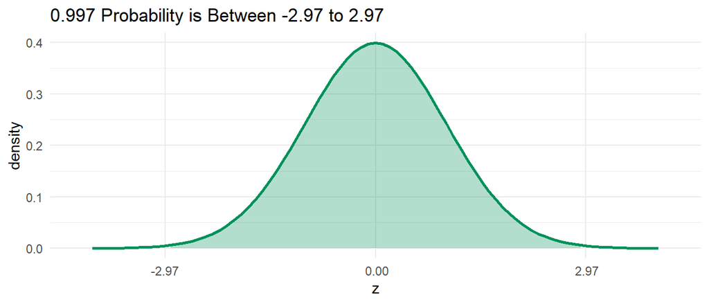

# Finding $z^{\star}$ Exactly

Find the $z^{\star}$ for a 92% confidence level.

**Process:**

- Confidence level is 0.92.
- Lower tail of the $Z \sim N(0,1)$ is $\frac{(1-0.92)}{2} = 0.04$.
- We want to find the $z$ score that would yield a 0.04 probability.
- Use the `qnorm()` function in R.

**Using R:**

```r
cl <- 0.92 # confidence level
lt <- (1-cl)/2 # lower tail probability
qnorm(lt,0,1) # computes the z star
```

```
## [1] -1.750686
```

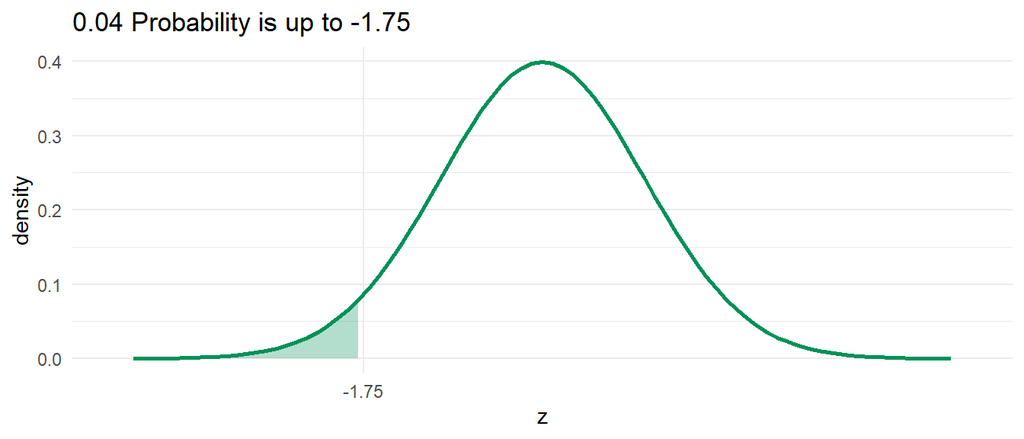

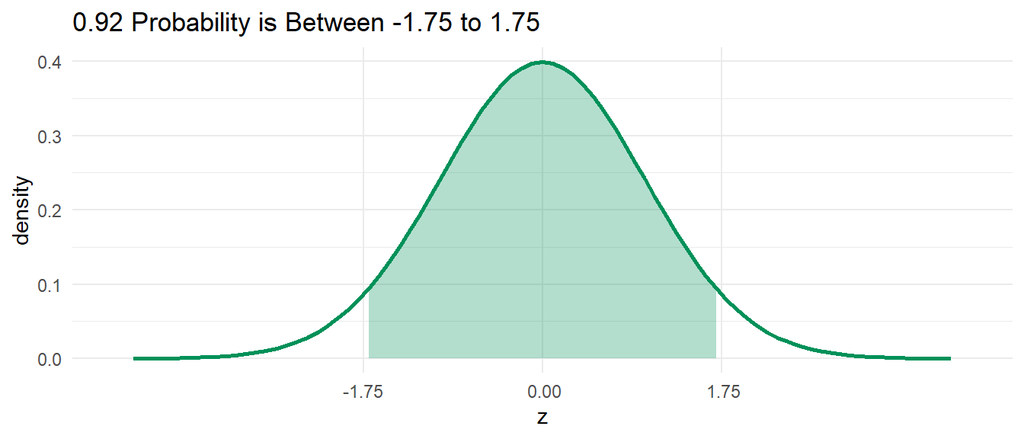